# Name: Hassan Mphammad

# ID: 2131117616

Load the the data from:

https://github.com/vega/vega-datasets/raw/gh-pages/data/cars.json

Then perform the proper steps to answer the questions in the cells

# Report:

| Variables | Description | Data type | Notes |
| --- | --- | --- | --- |
| Acceleration | tell the acceleration to each car with acceleration mean of 15.5 | continues, float | _ |
| Cylinders | describe the amount of cylinders in each car | categorical, float | _ |
| Displacement | tells Displacement the car can make | continues, float | _ |
| Horsepower | tells the power of each car engine in horses | continues, float | 6 values are missing |
| Miles_per_Gallon | describe how many miles the car can travel for gallon | continues, float | 8 values are missing |
| Name | tells the name of each car | continues, object | _ |
| Origin | the origin of the car, where the car was made | categorical, Object | _ |
| Weight_in_lbs | tells the weight of cars in lbs | continues, float | _ |
| Year | tells which year the car was made in | continues, object | should be datetime |

- The frequency of the 4 cylinders car are more in above average miles per gallon while the frequency of the 8 cylinders car are more in below average miles per gallon.
- Cars with 4 cylinders have more miles per gallon than cars with 6 or 8 cylinders, cars with 4 cylinders are more.
- USA is the most country that make 8 cylinders cars.

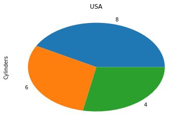

- Japan and Europe most of their cars are 4 and 6 cylinders.

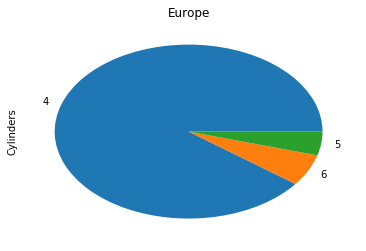

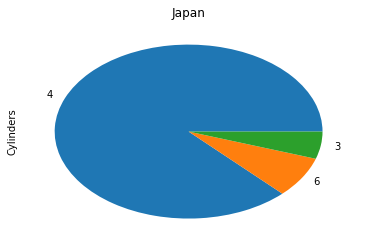

- USA care more about the engine power more then the economic cars.
- Europe and Japan don't care about the power of the car engine as much of the car economic that doesn't burn to much fuel.

1- fuel in Japan and Europe are more expensive than USA.

2- people in USA love speed and racing.

clean_cars_df.Cylinders[(clean_cars_df.Miles_per_Gallon <= 15)].hist()

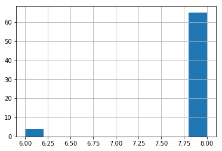

clean_cars_df.Origin[(clean_cars_df.Miles_per_Gallon <= 15)].value_counts().plot(kind="bar")

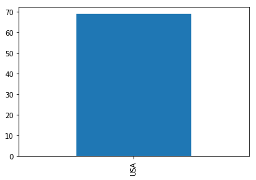

**as the graphs shows:**

- the cars that has low miles per gallon are 8 cylinder cars and made in USA and they are the lowest miles per gallon in the dataframe.